# Use Random Forest in classification

```r
# create a random forest classification task
rf_task <- makeClassifTask(id = "dt", data = training_set,
                           target ="TenYearCHD")
rf_task
```

```
## Supervised task: dt
## Type: classif
## Target: TenYearCHD
## Observations: 3702
## Features:
##    numerics     factors     ordered functionals
##          14           0           0           0
## Missings: FALSE
## Has weights: FALSE
## Has blocking: FALSE
## Has coordinates: FALSE
## Classes: 2
##    0    1
## 1783 1919
## Positive class: 0
```

```r
# check parameter sets of learner
getParamSet(makeLearner("classif.randomForest"))
```

```
##                      Type  len   Def   Constr Req Tunable Trafo
## ntree             integer    -   500 1 to Inf   -    TRUE     -
## mtry              integer    -     - 1 to Inf   -    TRUE     -
## replace           logical    -  TRUE        -   -    TRUE     -
## classwt     numericvector <NA>     - 0 to Inf   -    TRUE     -
## cutoff      numericvector <NA>     -   0 to 1   -    TRUE     -
## strata            untyped    -     -        -   -   FALSE     -
## sampsize    integervector <NA>     - 1 to Inf   -    TRUE     -
## nodesize          integer    -     1 1 to Inf   -    TRUE     -
## maxnodes          integer    -     - 1 to Inf   -    TRUE     -
## importance        logical    - FALSE        -   -    TRUE     -
## localImp          logical    - FALSE        -   -    TRUE     -
## proximity         logical    - FALSE        -   -   FALSE     -
## oob.prox          logical    -     -        -   Y   FALSE     -
## norm.votes        logical    -  TRUE        -   -   FALSE     -
## do.trace          logical    - FALSE        -   -   FALSE     -
## keep.forest       logical    -  TRUE        -   -   FALSE     -
## keep.inbag        logical    - FALSE        -   -   FALSE     -
```

```r
getHyperPars(makeLearner("classif.randomForest"))
```

```
## named list()
```

```r
# create a rf with the following setting:
rf_lrn <- makeLearner("classif.randomForest", predict.type = "prob",
                      fix.factors.prediction = TRUE)
rf_lrn
```

```
## Learner classif.randomForest from package randomForest
## Type: classif
## Name: Random Forest; Short name: rf
## Class: classif.randomForest
## Properties: twoclass,multiclass,numerics,factors,ordered,prob,class.weights,oobpreds,featimp
## Predict-Type: prob
## Hyperparameters:
```

```r
# train the decision tree classifier
rf_mod <- train(rf_lrn, rf_task)
rf_mod$learner.model
```

```
##
## Call:
##  randomForest(formula = f, data = data, classwt = classwt, cutoff = cutoff)
##                Type of random forest: classification
##                      Number of trees: 500
## No. of variables tried at each split: 3
##
##         OOB estimate of  error rate: 4.48%
## Confusion matrix:
##      0    1 class.error
## 0 1623  160 0.089736399
## 1    6 1913 0.003126628
```

```r
rf_mod$features
```

```
##  [1] "age"             "sex"             "is_smoking"      "cigsPerDay"
##  [5] "BPMeds"          "prevalentStroke" "prevalentHyp"    "diabetes"
##  [9] "totChol"         "sysBP"           "diaBP"           "BMI"
## [13] "heartRate"       "glucose"
```

```r
rf_mod$time
```

```
## [1] 3.47
```

```r
train_pred <- predict(rf_mod, rf_task); train_pred
```

```
## Prediction: 3702 observations
## predict.type: prob
## threshold: 0=0.50,1=0.50
## time: 0.20
##    id truth prob.0 prob.1 response
## 1   1     1  0.016  0.984        1
## 3   2     1  0.008  0.992        1
## 6   3     1  0.010  0.990        1
## 7   4     1  0.070  0.930        1
## 9   5     1  0.036  0.964        1
## 10  6     1  0.064  0.936        1
## ... (#rows: 3702, #cols: 5)
```

```r
test_pred <- predict(rf_mod, newdata=test_set); test_pred
```

```
## Prediction: 1587 observations
## predict.type: prob
## threshold: 0=0.50,1=0.50
## time: 0.09
##    truth prob.0 prob.1 response
## 2      1  0.086  0.914        1
## 4      1  0.204  0.796        1
## 5      1  0.042  0.958        1
## 8      1  0.344  0.656        1
## 11     1  0.090  0.910        1
## 16     1  0.216  0.784        1
## ... (#rows: 1587, #cols: 4)
```

```r
# confusion matrix
calculateConfusionMatrix(train_pred)
```

```
##         predicted
## true        0    1 -err.-
##   0      1783    0      0
##   1         0 1919      0
##   -err.-    0    0      0
```

```r
calculateConfusionMatrix(test_pred)
```

```
##         predicted
## true       0   1 -err.-
##   0      695  69     69
##   1        2 821      2
##   -err.-   2  69     71
```

```r
# Relative confusion matrix (normalized by row/column)
calculateConfusionMatrix(train_pred, relative = TRUE, sums = TRUE)
```

```
## Relative confusion matrix (normalized by row/column):
##         predicted
## true     0         1         -err.-    -n-
##   0      1.00/1.00 0.00/0.00 0.00      1783
##   1      0.00/0.00 1.00/1.00 0.00      1919
##   -err.-      0.00      0.00 0.00      <NA>
##   -n-    1783      1919      <NA>      3702
##
##
## Absolute confusion matrix:
##           0    1 -err.-  -n-
## 0      1783    0      0 1783
## 1         0 1919      0 1919
## -err.-    0    0      0   NA
## -n-    1783 1919     NA 3702
```

```r
calculateConfusionMatrix(test_pred, relative = TRUE, sums = TRUE)
```

```
## Relative confusion matrix (normalized by row/column):
##         predicted
## true     0           1           -err.-      -n-
##   0      0.910/0.997 0.090/0.078 0.090       697
##   1      0.002/0.003 0.998/0.922 0.002       890
##   -err.-       0.003       0.078 0.04        <NA>
##   -n-    764         823         <NA>        3702
##
##
## Absolute confusion matrix:
##          0   1 -err.-  -n-
## 0      695  69     69  764
## 1        2 821      2  823
## -err.-   2  69     71   NA
## -n-    697 890     NA 3702
```

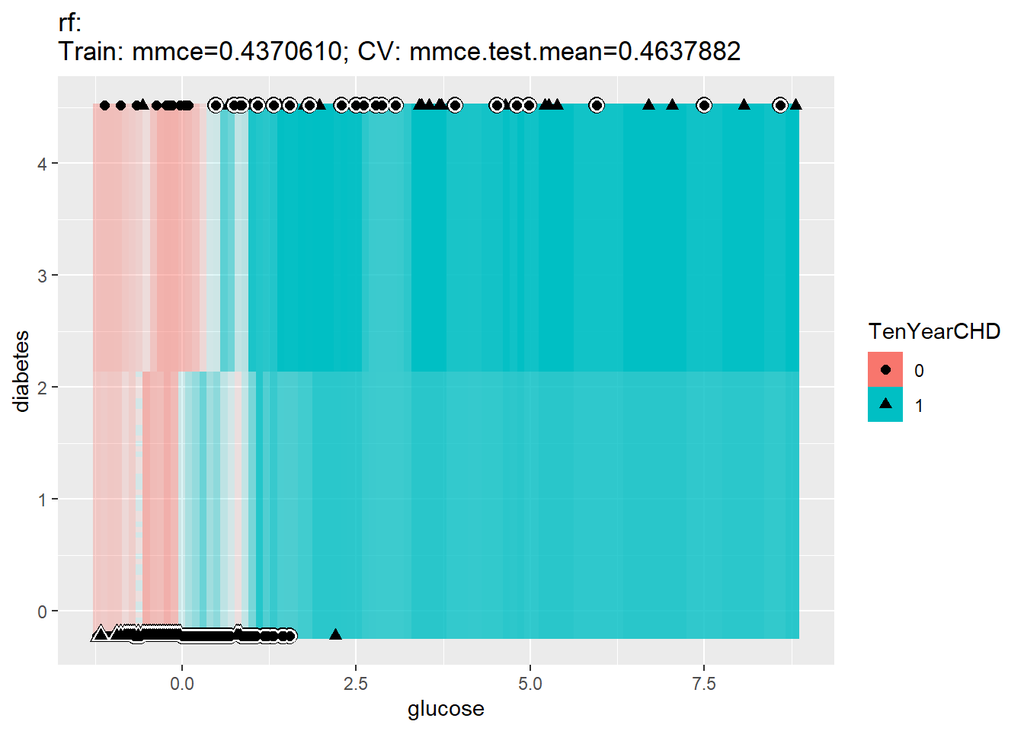

```r
# Visualizing the prediction
plotLearnerPrediction(rf_lrn, task = rf_task,
                      features = c("glucose", "diabetes"))
```

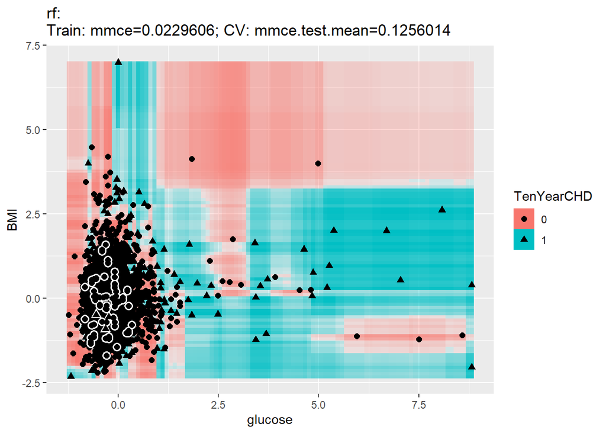

```r
plotLearnerPrediction(rf_lrn, task = rf_task,
                      features = c("glucose", "BMI"))
```

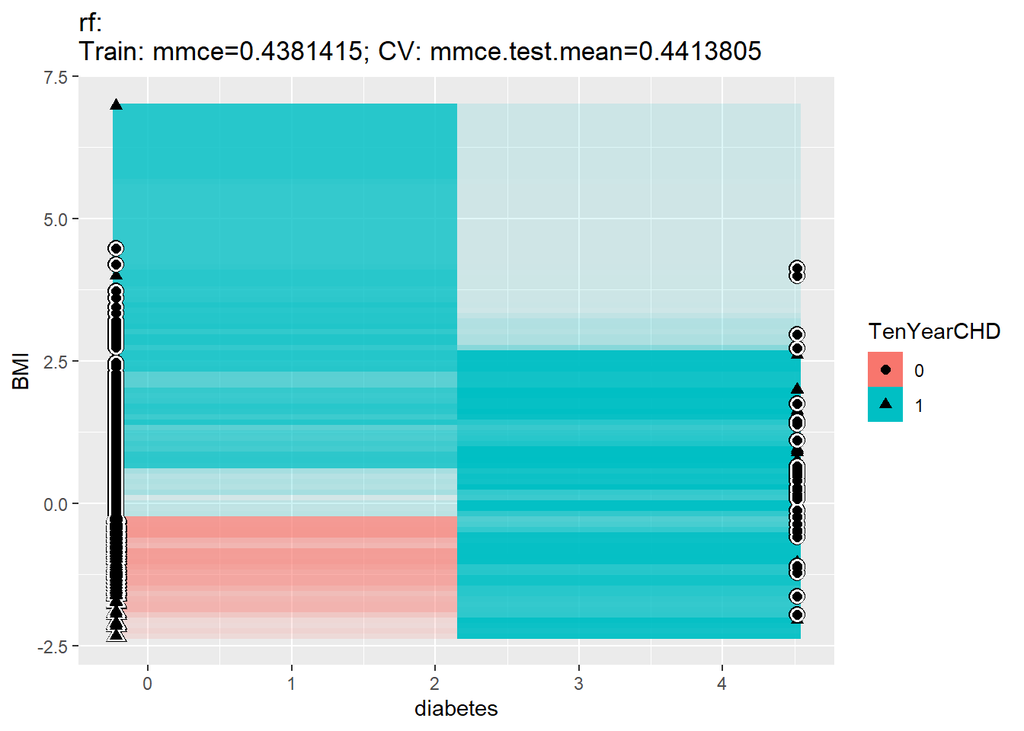

```r
plotLearnerPrediction(rf_lrn, task = rf_task,
                      features = c("diabetes", "BMI"))
```

```r
### Performance measure suitable for random forest classification task
listMeasures(rf_task)
```

```
##  [1] "tnr"              "tpr"              "featperc"         "f1"
##  [5] "mmce"             "mcc"              "brier.scaled"     "lsr"
##  [9] "bac"              "fn"               "fp"               "fnr"
## [13] "qsr"              "fpr"              "npv"              "brier"
## [17] "auc"              "timeboth"         "multiclass.aunp"  "timetrain"
## [21] "multiclass.aunu"  "ber"              "timepredict"      "multiclass.brier"
## [25] "ssr"              "ppv"              "acc"              "logloss"
## [29] "wkappa"           "tn"               "tp"               "multiclass.au1p"
## [33] "multiclass.au1u"  "fdr"              "kappa"            "gpr"
## [37] "gmean"
```

```r
### Get the default measure for random forest learner
getDefaultMeasure(rf_lrn)
```

```
## Name: Mean misclassification error
## Performance measure: mmce
## Properties: classif,classif.multi,req.pred,req.truth
## Minimize: TRUE
## Best: 0; Worst: 1
## Aggregated by: test.mean
## Arguments:
## Note: Defined as: mean(response != truth)
```

```r
# performance of prediction
performance(test_pred) # default mmce
```

```
##      mmce
## 0.0447385
```

```r
performance(test_pred, measures=acc)
```

```
##       acc
## 0.9552615
```

For random forest For relative confusion matrix between diabetes and glucose, patients who has over 1 numerical value of glucose tend to have CHD in 10 years no matter they have diabetes or not. For relative confusion matrix between BMI and glucose, patients who has over 1 numerical value of glucose and over 2.5 numerical value of BMI are not tend to have CHD in 10 years. For relative confusion matrix between BMI and diabetes, patients who has over 0.5 numerical value of BMI and no diabetes are tend to have CHD in 10 years.

```r
## Define the resampling strategy
set.seed(800)
rdesc <- makeResampleDesc(method = "CV", iters=10)
# tune ntree
discrete_ps <- makeParamSet(
  makeDiscreteParam("ntree", values=c(100, 200, 300, 400, 500))
)
ctrl_d <- makeTuneControlGrid()
res <- tuneParams(rf_lrn, task = rf_task,
                  resampling = rdesc,
                  par.set = discrete_ps,
                  control = ctrl_d,
                  measures = list(acc, mmce),
                  show.info = TRUE)
```

```
## [Tune] Started tuning learner classif.randomForest for parameter set:
```

```
##           Type len Def              Constr Req Tunable Trafo
## ntree discrete   -   - 100,200,300,400,500   -    TRUE     -
```

```
## With control class: TuneControlGrid
```

```
## Imputation value: -0Imputation value: 1
```

```
## [Tune-x] 1: ntree=100
```

```
## [Tune-y] 1: acc.test.mean=0.9470576,mmce.test.mean=0.0529424; time: 0.1 min
```

```
## [Tune-x] 2: ntree=200
```

```
## [Tune-y] 2: acc.test.mean=0.9492183,mmce.test.mean=0.0507817; time: 0.2 min
```

```
## [Tune-x] 3: ntree=300
```

```
## [Tune-y] 3: acc.test.mean=0.9481372,mmce.test.mean=0.0518628; time: 0.3 min
```

```
## [Tune-x] 4: ntree=400
```

```
## [Tune-y] 4: acc.test.mean=0.9478684,mmce.test.mean=0.0521316; time: 0.3 min
```

```
## [Tune-x] 5: ntree=500
```

```
## [Tune-y] 5: acc.test.mean=0.9481380,mmce.test.mean=0.0518620; time: 0.4 min
```

```
## [Tune] Result: ntree=200 : acc.test.mean=0.9492183,mmce.test.mean=0.0507817
```

```r
res
```

```
## Tune result:
## Op. pars: ntree=200
## acc.test.mean=0.9492183,mmce.test.mean=0.0507817
```

```r
res$x
```

```
## $ntree
## [1] 200
```

```r
res$y
```

```
##  acc.test.mean mmce.test.mean
##     0.94921833     0.05078167
```

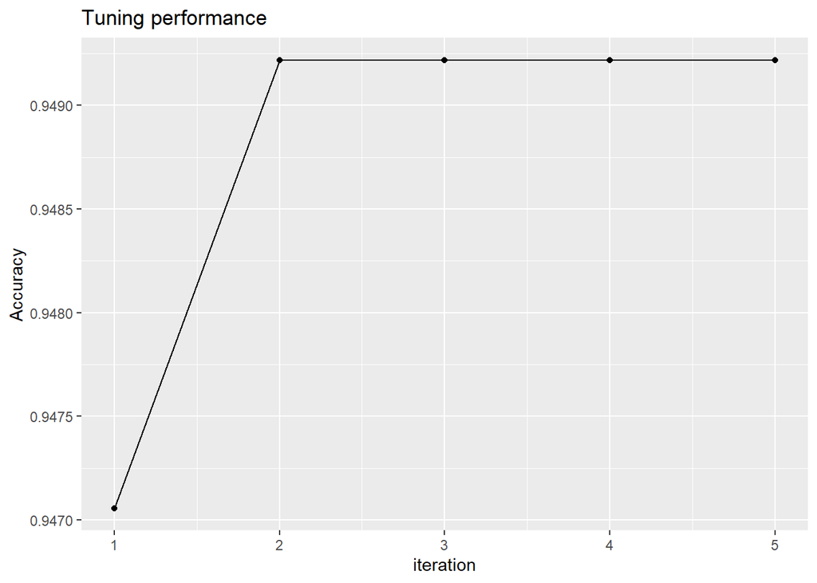

```r
#investigating hyperparameter tuning effects
data <- generateHyperParsEffectData(res, trafo=TRUE)
pl <- plotHyperParsEffect(data, x = "iteration", y = "acc.test.mean",
                          plot.type = "line")
library(ggplot2)
# use ggplot2 function to change y-axis label and add title
pl + ggtitle("Tuning performance") + ylab("Accuracy")
```

```r
# update the hyperparameter
rf_lrn <- setHyperPars(rf_lrn, par.vals = res$x)
rf_lrn
```

```
## Learner classif.randomForest from package randomForest
## Type: classif
## Name: Random Forest; Short name: rf
## Class: classif.randomForest
## Properties: twoclass,multiclass,numerics,factors,ordered,prob,class.weights,oobpreds,featimp
## Predict-Type: prob
## Hyperparameters: ntree=200
```

```r
# retrain the model
rf_mod <- train(rf_lrn, rf_task)
rf_mod
```

```
## Model for learner.id=classif.randomForest; learner.class=classif.randomForest
## Trained on: task.id = dt; obs = 3702; features = 14
## Hyperparameters: ntree=200
```

```r
# prediction
test_pred<-predict(rf_mod, newdata = test_set)
# Relative confusion matrix (normalized by row/column)
calculateConfusionMatrix(test_pred, relative = TRUE, sums = TRUE)
```

```
## Relative confusion matrix (normalized by row/column):
##         predicted
## true     0           1           -err.-      -n-
##   0      0.903/0.997 0.097/0.083 0.097       692
##   1      0.002/0.003 0.998/0.917 0.002       895
##   -err.-       0.003       0.083 0.05        <NA>
##   -n-    764         823         <NA>        3702
##
##
## Absolute confusion matrix:
##          0   1 -err.-  -n-
## 0      690  74     74  764
## 1        2 821      2  823
## -err.-   2  74     76   NA
## -n-    692 895     NA 3702
```

```r
# performance of prediction


performance(test_pred) # default mmce
```

```
##      mmce
## 0.0478891
```

```r
performance(test_pred, measures=acc)
```

```
##       acc
## 0.9521109
```

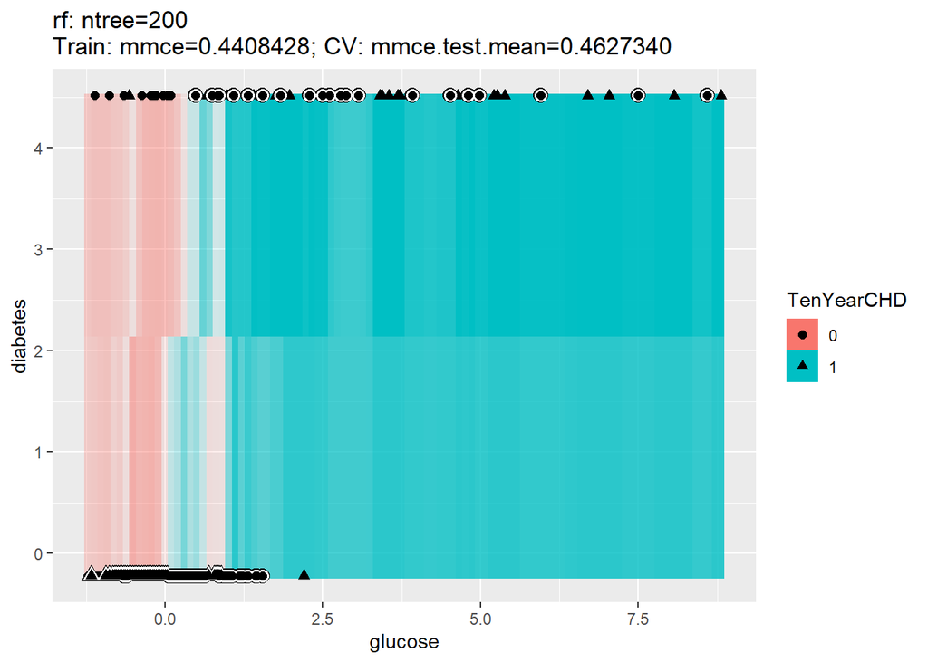

```r
# Visualizing the prediction
plotLearnerPrediction(rf_lrn, task = rf_task,
                      features = c("glucose", "diabetes"))
```

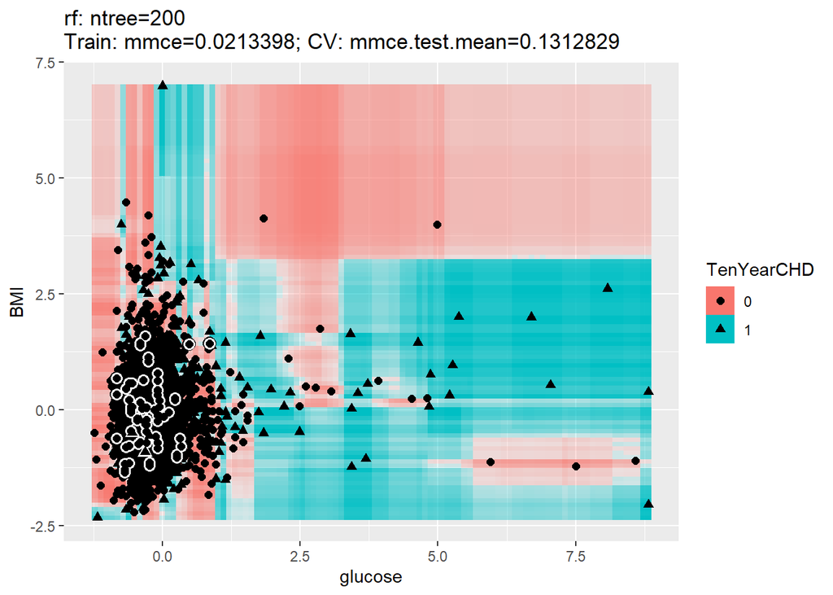

```r
plotLearnerPrediction(rf_lrn, task = rf_task,
                      features = c("glucose", "BMI"))
```